# Bellabeat

Let’s visualize and compare the weekly very active minutes of the 6 participants

```r
#Rename columns to Week1, Week2, Week3, Week4
names(w1w2w3w4_common)[2] <- 'week1'
names(w1w2w3w4_common)[3] <- 'week2'
names(w1w2w3w4_common)[4] <- 'week3'
names(w1w2w3w4_common)[5] <- 'week4'
#Covert wide dataset to long
w1234_common_long <- w1w2w3w4_common %>%
  gather("week", "minutes", -Id)
#Convert the Id field from numeric to character for ease of plotting and check
w1234_common_long$Id <- as.character((w1234_common_long$Id))
str(w1234_common_long)
```

```
## 'data.frame':    24 obs. of  3 variables:
##  $ Id     : chr  "1503960366" "5577150313" "7086361926" "8053475328" ...
##  $ week   : chr  "week1" "week1" "week1" "week1" ...
##  $ minutes: int  221 832 216 771 545 548 316 662 300 711 ...
```

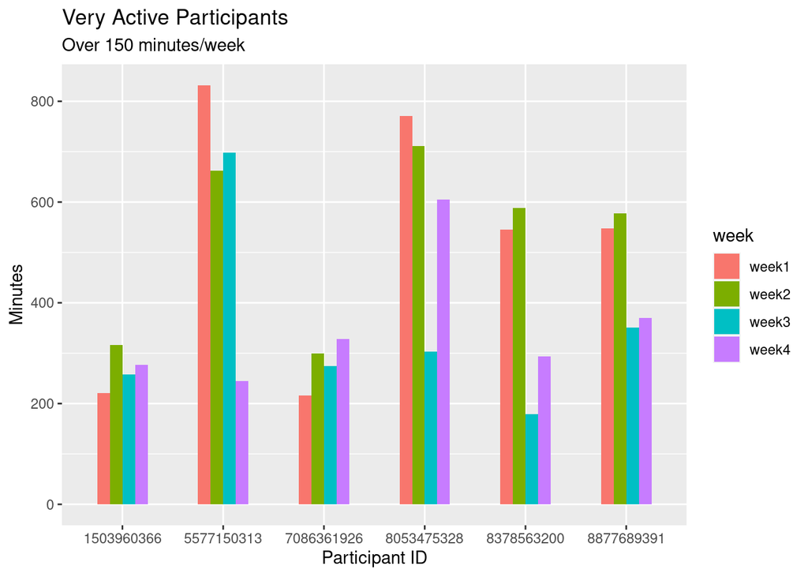

```r
#Plot the very active minutes
ggplot(w1234_common_long, aes(x=Id, y=minutes, fill= week, width = 0.5)) +
  geom_col(position = "dodge")+
  ggtitle("Very Active Participants", subtitle = "Over 150 minutes/week") +
  xlab("Participant ID") + ylab("Minutes")
```

Next, let’s explore if there is any correlation between length of VeryActiveMinutes and quality of sleep. I would like to look at activity versus %time asleep out of total time in bed.

Uploading sleepDay_merged file after changing the format of SleepDay column to YYYY-MM-DD in excel.

```r
sleep_day <- read.csv("sleepDay_merged.csv")
head(sleep_day)
```

```
##           Id        SleepDay TotalSleepRecords TotalMinutesAsleep
## 1 1503960366 2016-04-12 0:00                 1                327
## 2 1503960366 2016-04-13 0:00                 2                384
## 3 1503960366 2016-04-15 0:00                 1                412
## 4 1503960366 2016-04-16 0:00                 2                340
## 5 1503960366 2016-04-17 0:00                 1                700
## 6 1503960366 2016-04-19 0:00                 1                304
##   TotalTimeInBed
## 1            346
## 2            407
## 3            442
## 4            367
## 5            712
## 6            320
```

```r
glimpse(sleep_day)
```

```
## Rows: 413
## Columns: 5
## $ Id                 <dbl> 1503960366, 1503960366, 1503960366, 1503960366, 150…
## $ SleepDay           <chr> "2016-04-12 0:00", "2016-04-13 0:00", "2016-04-15 0…
## $ TotalSleepRecords  <int> 1, 2, 1, 2, 1, 1, 1, 1, 1, 1, 1, 1, 1, 1, 1, 1, 1, …
## $ TotalMinutesAsleep <int> 327, 384, 412, 340, 700, 304, 360, 325, 361, 430, 2…
## $ TotalTimeInBed     <int> 346, 407, 442, 367, 712, 320, 377, 364, 384, 449, 3…
```

SleepDay column is in the format “yyyy-mm-dd hh:mm”. Split the column to seperate date from time

```r
sleep_day <- tidyr::separate(
  data = sleep_day,
  col = SleepDay,
  sep = " ",
  into = c("date","time"),
  remove = FALSE
)
head(sleep_day)
```

```
##           Id        SleepDay       date time TotalSleepRecords
## 1 1503960366 2016-04-12 0:00 2016-04-12 0:00                 1
## 2 1503960366 2016-04-13 0:00 2016-04-13 0:00                 2
## 3 1503960366 2016-04-15 0:00 2016-04-15 0:00                 1
## 4 1503960366 2016-04-16 0:00 2016-04-16 0:00                 2
## 5 1503960366 2016-04-17 0:00 2016-04-17 0:00                 1
## 6 1503960366 2016-04-19 0:00 2016-04-19 0:00                 1
##   TotalMinutesAsleep TotalTimeInBed
## 1                327            346
## 2                384            407
## 3                412            442
## 4                340            367
## 5                700            712
## 6                304            320
```

```r
glimpse(sleep_day)
```

```
## Rows: 413
## Columns: 7
## $ Id                 <dbl> 1503960366, 1503960366, 1503960366, 1503960366, 150…
## $ SleepDay           <chr> "2016-04-12 0:00", "2016-04-13 0:00", "2016-04-15 0…
## $ date               <chr> "2016-04-12", "2016-04-13", "2016-04-15", "2016-04-…
## $ time               <chr> "0:00", "0:00", "0:00", "0:00", "0:00", "0:00", "0:…
## $ TotalSleepRecords  <int> 1, 2, 1, 2, 1, 1, 1, 1, 1, 1, 1, 1, 1, 1, 1, 1, 1, …
## $ TotalMinutesAsleep <int> 327, 384, 412, 340, 700, 304, 360, 325, 361, 430, 2…
## $ TotalTimeInBed     <int> 346, 407, 442, 367, 712, 320, 377, 364, 384, 449, 3…
```

In order to merge the sleep_day dataset with daily_activity dataset I have to create primary and foreign key columns. I’ll do that by combining the Id field with the date field in each dataset.

```r
#sleep dataset
sleep_day$Id_date <- paste(sleep_day$Id,"-", sleep_day$date)
head(sleep_day)
```

```
##           Id        SleepDay       date time TotalSleepRecords
## 1 1503960366 2016-04-12 0:00 2016-04-12 0:00                 1
## 2 1503960366 2016-04-13 0:00 2016-04-13 0:00                 2
## 3 1503960366 2016-04-15 0:00 2016-04-15 0:00                 1
## 4 1503960366 2016-04-16 0:00 2016-04-16 0:00                 2
## 5 1503960366 2016-04-17 0:00 2016-04-17 0:00                 1
## 6 1503960366 2016-04-19 0:00 2016-04-19 0:00                 1
##   TotalMinutesAsleep TotalTimeInBed                 Id_date
## 1                327            346 1503960366 - 2016-04-12
## 2                384            407 1503960366 - 2016-04-13
## 3                412            442 1503960366 - 2016-04-15
## 4                340            367 1503960366 - 2016-04-16
## 5                700            712 1503960366 - 2016-04-17
## 6                304            320 1503960366 - 2016-04-19
```

```r
#daily_activity dataset
daily_activity$Id_date <- paste(daily_activity$Id,"-",daily_activity$ActivityDate)
head(daily_activity)
```

```
##           Id ActivityDate TotalSteps TotalDistance TrackerDistance
## 1 1503960366   2016-04-12      13162          8.50            8.50
## 2 1503960366   2016-04-13      10735          6.97            6.97
## 3 1503960366   2016-04-14      10460          6.74            6.74
## 4 1503960366   2016-04-15       9762          6.28            6.28
## 5 1503960366   2016-04-16      12669          8.16            8.16
## 6 1503960366   2016-04-17       9705          6.48            6.48
##   LoggedActivitiesDistance VeryActiveDistance ModeratelyActiveDistance
## 1                        0               1.88                     0.55
## 2                        0               1.57                     0.69
## 3                        0               2.44                     0.40
## 4                        0               2.14                     1.26
## 5                        0               2.71                     0.41
## 6                        0               3.19                     0.78
##   LightActiveDistance SedentaryActiveDistance VeryActiveMinutes
```

[output cut: 20 more lines]

Calculate percent of time participant is asleep in bed

```r
sleep_day <- mutate(sleep_day,sleep_percent = (TotalMinutesAsleep/TotalTimeInBed)*100)
head(sleep_day)
```

```
##           Id        SleepDay       date time TotalSleepRecords
## 1 1503960366 2016-04-12 0:00 2016-04-12 0:00                 1
## 2 1503960366 2016-04-13 0:00 2016-04-13 0:00                 2
## 3 1503960366 2016-04-15 0:00 2016-04-15 0:00                 1
## 4 1503960366 2016-04-16 0:00 2016-04-16 0:00                 2
## 5 1503960366 2016-04-17 0:00 2016-04-17 0:00                 1
## 6 1503960366 2016-04-19 0:00 2016-04-19 0:00                 1
##   TotalMinutesAsleep TotalTimeInBed                 Id_date sleep_percent
## 1                327            346 1503960366 - 2016-04-12      94.50867
## 2                384            407 1503960366 - 2016-04-13      94.34889
## 3                412            442 1503960366 - 2016-04-15      93.21267
## 4                340            367 1503960366 - 2016-04-16      92.64305
## 5                700            712 1503960366 - 2016-04-17      98.31461
## 6                304            320 1503960366 - 2016-04-19      95.00000
```

Do an inner_join on the two datasets to only include records that have common day and Id.

```r
activity_vs_sleep <- sleep_day %>% inner_join(daily_activity, by="Id_date")
head(activity_vs_sleep)
```

```
##         Id.x        SleepDay       date time TotalSleepRecords
## 1 1503960366 2016-04-12 0:00 2016-04-12 0:00                 1
## 2 1503960366 2016-04-13 0:00 2016-04-13 0:00                 2
## 3 1503960366 2016-04-15 0:00 2016-04-15 0:00                 1
## 4 1503960366 2016-04-16 0:00 2016-04-16 0:00                 2
## 5 1503960366 2016-04-17 0:00 2016-04-17 0:00                 1
## 6 1503960366 2016-04-19 0:00 2016-04-19 0:00                 1
##   TotalMinutesAsleep TotalTimeInBed                 Id_date sleep_percent
## 1                327            346 1503960366 - 2016-04-12      94.50867
## 2                384            407 1503960366 - 2016-04-13      94.34889
## 3                412            442 1503960366 - 2016-04-15      93.21267
## 4                340            367 1503960366 - 2016-04-16      92.64305
## 5                700            712 1503960366 - 2016-04-17      98.31461
## 6                304            320 1503960366 - 2016-04-19      95.00000
##         Id.y ActivityDate TotalSteps TotalDistance TrackerDistance
```

[output cut: 34 more lines]

Now we can plot time asleep in bed against the day’s very active minutes

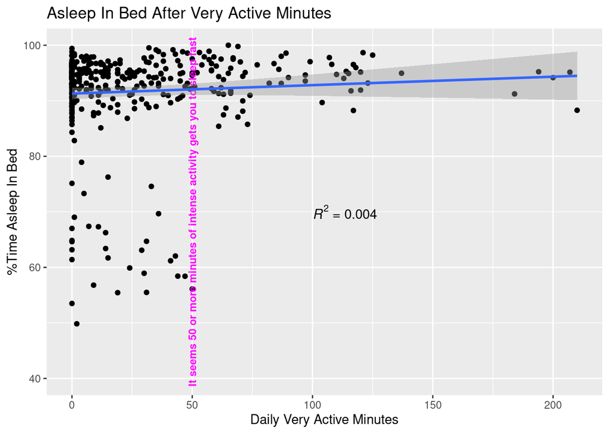

```r
ggplot(data=activity_vs_sleep)  +
  geom_point(mapping=aes(x=VeryActiveMinutes, y=sleep_percent)) +
  scale_y_continuous(limits = c(40, 100.00000000)) +
  xlab("Daily Very Active Minutes") + ylab("%Time Asleep In Bed")+
  labs(title = "Asleep In Bed After Very Active Minutes") +
  annotate("text", x=50, y = 70,
           label = "It seems 50 or more minutes of intense activity gets you to sleep fast",
           color="magenta", fontface='bold', size=3.1, angle=90)+
  stat_smooth(method="lm", aes(x=VeryActiveMinutes, y=sleep_percent))+
  stat_regline_equation(label.x=100, label.y=70,aes(x=VeryActiveMinutes, y=sleep_percent,
                            label = ..rr.label..))
```

Almost all except a few data points fall above the 80% line. Let’s look at the participants that less than 80% of time in bed asleep

```r
toss_turn <- filter(activity_vs_sleep, activity_vs_sleep$sleep_percent < 80)
head(toss_turn)
```

```
##         Id.x        SleepDay       date time TotalSleepRecords
## 1 1844505072 2016-04-15 0:00 2016-04-15 0:00                 1
## 2 1844505072 2016-04-30 0:00 2016-04-30 0:00                 1
## 3 1844505072 2016-05-01 0:00 2016-05-01 0:00                 1
## 4 3977333714 2016-04-12 0:00 2016-04-12 0:00                 1
## 5 3977333714 2016-04-13 0:00 2016-04-13 0:00                 2
## 6 3977333714 2016-04-14 0:00 2016-04-14 0:00                 1
##   TotalMinutesAsleep TotalTimeInBed                 Id_date sleep_percent
## 1                644            961 1844505072 - 2016-04-15      67.01353
## 2                722            961 1844505072 - 2016-04-30      75.13007
## 3                590            961 1844505072 - 2016-05-01      61.39438
## 4                274            469 3977333714 - 2016-04-12      58.42217
## 5                295            456 3977333714 - 2016-04-13      64.69298
## 6                291            397 3977333714 - 2016-04-14      73.29975
##         Id.y ActivityDate TotalSteps TotalDistance TrackerDistance
```

[output cut: 34 more lines]

We find that 28 of the 31 data points below 80% asleep time belong to the same participant (Id# 3977333714). This suggests this participant is an outlier. Exclude from the dataset particiapnt Id 3977333714.

```r
no_toss_turn <- activity_vs_sleep %>% filter_all(all_vars(.!=3977333714))
```

Let’s plot time asleep in bed against the day’s very active minutes again.

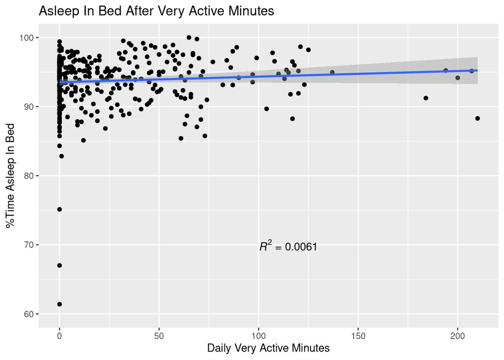

```r
ggplot(data=no_toss_turn)  +
  geom_point(mapping=aes(x=VeryActiveMinutes, y=sleep_percent)) +
  scale_y_continuous(limits = c(60, 100.00000000)) +
  xlab("Daily Very Active Minutes") + ylab("%Time Asleep In Bed")+
  labs(title = "Asleep In Bed After Very Active Minutes")+
  stat_smooth(method="lm", aes(x=VeryActiveMinutes, y=sleep_percent))+
  stat_regline_equation(label.x=100, label.y=70,aes(x=VeryActiveMinutes, y=sleep_percent,label = ..rr.label..))
```

When the data is plotted again, it shows activity level does not have any impact on time spent awake in bed.

Exploring the correlation with lower levels of activity

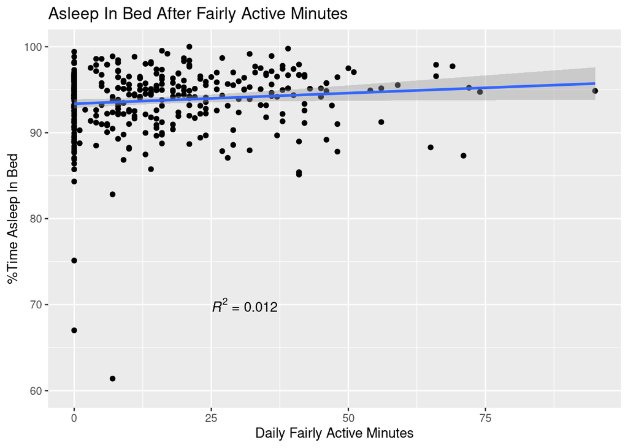

```r
#Farily Active
ggplot(data=no_toss_turn)  +
  geom_point(mapping=aes(x=FairlyActiveMinutes, y=sleep_percent)) +
  scale_y_continuous(limits = c(60, 100.00000000)) +
  xlab("Daily Fairly Active Minutes") + ylab("%Time Asleep In Bed")+
  labs(title = "Asleep In Bed After Fairly Active Minutes")+
  stat_smooth(method="lm", aes(x=FairlyActiveMinutes, y=sleep_percent))+
  stat_regline_equation(label.x=25, label.y=70,aes(x=FairlyActiveMinutes, y=sleep_percent,
                            label = ..rr.label..))
```

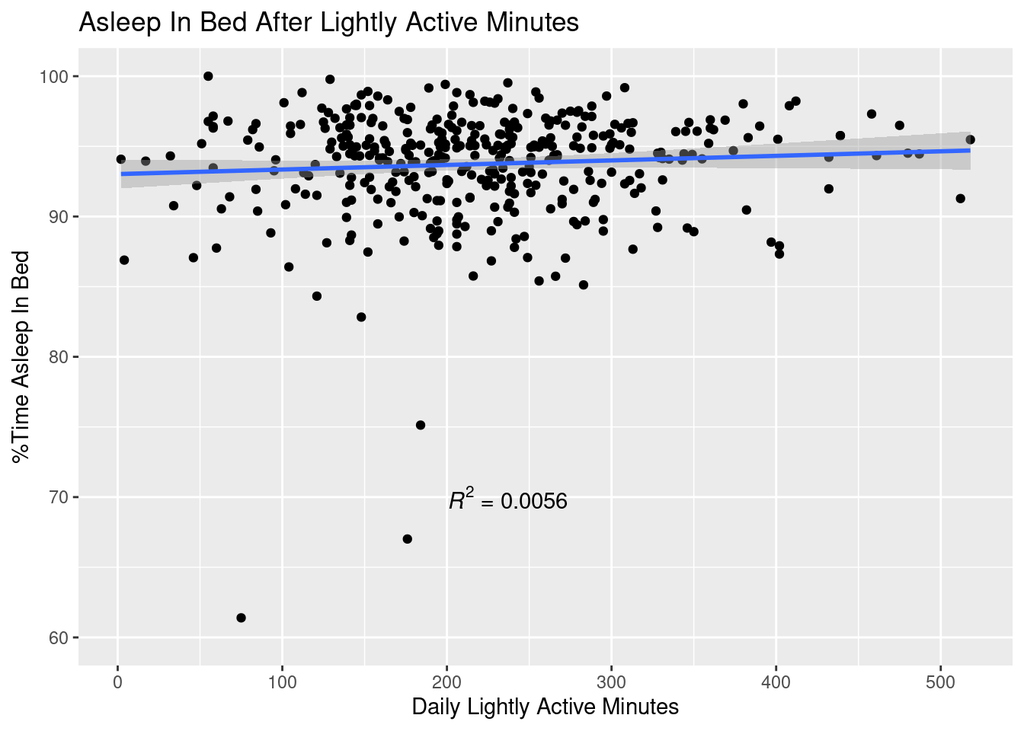

```r
#Lightly Active
ggplot(data=no_toss_turn)  +
  geom_point(mapping=aes(x=LightlyActiveMinutes, y=sleep_percent)) +
  scale_y_continuous(limits = c(60, 100.00000000)) +
  xlab("Daily Lightly Active Minutes") + ylab("%Time Asleep In Bed")+
  labs(title = "Asleep In Bed After Lightly Active Minutes")+
  stat_smooth(method="lm", aes(x=LightlyActiveMinutes, y=sleep_percent))+
  stat_regline_equation(label.x=200, label.y=70,aes(x=LightlyActiveMinutes, y=sleep_percent,
                            label = ..rr.label..))
```

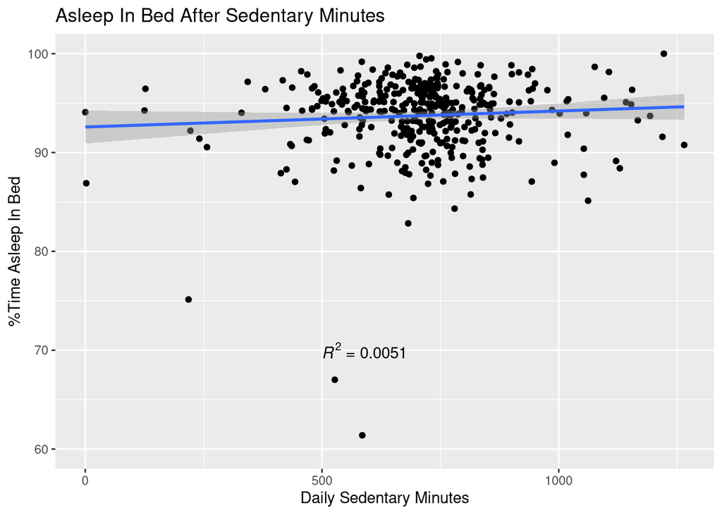

```r
#Sedentary
ggplot(data=no_toss_turn)  +
  geom_point(mapping=aes(x=SedentaryMinutes, y=sleep_percent)) +
  scale_y_continuous(limits = c(60, 100.00000000)) +
  xlab("Daily Sedentary Minutes") + ylab("%Time Asleep In Bed") +
  labs(title = "Asleep In Bed After Sedentary Minutes")+
  stat_smooth(method="lm", aes(x=SedentaryMinutes, y=sleep_percent))+
  stat_regline_equation(label.x=500, label.y=70, aes(x=SedentaryMinutes, y=sleep_percent, label = ..rr.label..))
```

None of the activity levels seem to have a correlation with what fraction of total time in bed the participant is actually asleep.

### Weight Data:

A review of the weight data available is completed in excel as it is limited and excel is a good tool for this purpose. Only 8 participants have logged their weight data and that too sporadically. Interestingly 3 out of those 8 are also on the list of 6 that consistently performed more than 150 minutes of VeryActive workout each week.  
Another observation on the weights data is that 5 of the 8 participants were logging weight manually even though Fitbit offers capabilities to sync with many weight measuring devices. Although this is a very small sample and not statistically valid, it suggests difficulty in logging weight. Perhaps syncing with devices is difficult and manual entry too cumbersome.

### Heartrate Data:

Heart rate data could have been very useful if it could be tied with workout intensity. However, workout intensity data is in hour intervals and heart rate is in second intervals. Since heartrates vary significantly during the course of exercising, summarizing to an hourly interval provides no value. Furthermore, target heartrate depends upon age according to the [American Heart Association](https://www.heart.org/en/healthy-living/fitness/fitness-basics/target-heart-rates) and our dataset does not include participant age.

## Insights:

1. Most activity occurs on Saturdays and least on Sundays.
2. Few participants (18%) consistently workout to meet the American Heart Association guidelines.
3. Fitbit monitors heart rate but the data is not summarized in a way to track improvement in cardiovascular health or compare with American Heart Association guidelines.
4. Few particpants log their weight. Further research is necessary to find out the reason. Is it inconvenient? Is there a disincentive? Other reasons?
5. Logging of sleep is lacking. Further research is necessary to find the reasons.
6. Activity level does not have any impact on how quickly participants fall off to sleep once they go to bed.
7. The best predictor of calories burned is the amount of distance traveled.